# Szczecin Accident Risk Predictor — v4

**Goal**: production model that takes **(time, cell_id, weather)** as input and returns the probability of an accident in a 6-hour window.

## Architectural decisions based on v3 results

From the v3 analysis:

- **XGBoost won all metrics** (PR-AUC 0.0186, Recall@1% = 0.51, ROC-AUC 0.964, spatial r = +0.93)
- **Stacking did not beat XGBoost solo** despite the standardization fix
- **Calibration broke PR-AUC** (0.0186 → 0.0160) while preserving ROC — the fallback worked, but the signal is clear: for top-K ranking tasks calibration is unnecessary
- **T-GCN/A3T-GCN did not beat gradient boosting** (PR-AUC 0.005-0.006 vs 0.019)

So the final stack is: **XGBoost** + **feature store snapshot** + a thin inference layer (the `AccidentRiskPredictor` class).

## Architecture

```
┌──────────────────────────────────────────────────────────────────┐
│                        Training (offline)                         │
│  raw data → feature engineering → XGBoost.fit() → model.json      │
│                          ↓                                         │
│              feature store snapshot → feature_store.pkl           │
└──────────────────────────────────────────────────────────────────┘
                                 ↓
┌──────────────────────────────────────────────────────────────────┐
│                       Inference (online)                          │
│  user input: (time, cell_id, weather)                             │
│       ↓                                                            │
│  AccidentRiskPredictor.predict():                                 │
│    1. snap time to 6h window {00, 06, 12, 18}                     │
│    2. lookup cell_past_rate, cell_hour_past_rate, etc. from store │
│    3. compute time-derived features (sin/cos, season, is_night)   │
│    4. compute weather interactions (slippery, frost, gust_ratio)  │
│    5. assemble feature vector in training order                   │
│    6. xgb.predict() → probability                                 │
└──────────────────────────────────────────────────────────────────┘
```

```python
from google.colab import drive
drive.mount('/content/drive')
```

## 1. Setup

```python
import warnings
warnings.filterwarnings('ignore')

from datetime import datetime
from pathlib import Path
from dataclasses import dataclass, field
from typing import Optional, Union, Sequence

import numpy as np
import pandas as pd
import scipy.sparse as sp
import matplotlib.pyplot as plt
from sklearn.preprocessing import StandardScaler
from sklearn.neighbors import BallTree
from sklearn.metrics import (
    roc_auc_score, average_precision_score,
    precision_recall_curve, roc_curve,
)
import xgboost as xgb

pd.set_option('display.max_columns', 60)
plt.rcParams['figure.dpi'] = 110

RANDOM_STATE = 42
np.random.seed(RANDOM_STATE)

ARTIFACT_DIR = Path('production_artifact')
ARTIFACT_DIR.mkdir(exist_ok=True)
print(f'Artifacts will be saved in: {ARTIFACT_DIR.resolve()}')
```

```
Artifacts will be saved in: /content/production_artifact
```

## 2. Data loading

```python
df = pd.read_csv('/content/drive/MyDrive/Szczecin Accident Risk/panel_data_with_weather.csv', parse_dates=['time_window'])

centroids = (
    pd.read_csv('/content/drive/MyDrive/Szczecin Accident Risk/panel_data.csv', usecols=['cell_id', 'centroid_x', 'centroid_y'])
    .drop_duplicates('cell_id')
    .set_index('cell_id')
)

df = df.join(centroids, on='cell_id')
df = df.sort_values(['cell_id', 'time_window']).reset_index(drop=True)

print(f'Rows:       {len(df):,}')
print(f'Cells:      {df["cell_id"].nunique()}')
print(f'Windows:    {df["time_window"].nunique()}')
print(f'Period:     {df["time_window"].min().date()} -> {df["time_window"].max().date()}')
print(f'Accidents:  {int(df["y_binary"].sum()):,} ({df["y_binary"].mean()*100:.4f}%)')
```

```
Rows:       4,331,392
Cells:      494
Windows:    8768
Period:     2020-01-01 -> 2025-12-31
Accidents:  1,496 (0.0345%)
```

## 3. Grid topology

Same as in v3 — graph of 8 nearest neighbors for each cell, used for `nb_*` neighborhood features and spatial lag.

```python
# Stable list of cell_id (sorted — internal index)
cell_ids = np.sort(df['cell_id'].unique())
n_cells = len(cell_ids)
cell_id_to_idx = {c: i for i, c in enumerate(cell_ids)}

coords = np.array([
    [centroids.loc[c, 'centroid_x'], centroids.loc[c, 'centroid_y']]
    for c in cell_ids
])

K = 8
tree = BallTree(coords)
dists, idx_neigh = tree.query(coords, k=K + 1)
idx_neigh = idx_neigh[:, 1:]
dists = dists[:, 1:]

rows = np.repeat(np.arange(n_cells), K)
cols = idx_neigh.flatten()
vals = np.full(rows.shape, 1.0 / K)

A_mean = sp.csr_matrix((vals, (rows, cols)), shape=(n_cells, n_cells))
A_sum = sp.csr_matrix((np.ones_like(vals), (rows, cols)), shape=(n_cells, n_cells))

print(f'Number of cells: {n_cells}')
print(f'A_mean: shape={A_mean.shape}, nnz={A_mean.nnz}')
```

```
Number of cells: 494
A_mean: shape=(494, 494), nnz=3952
```

## 4. Feature engineering

Pipeline identical to v3 (we know it works): conditional rates, spatial lag, TSLA, neighbor aggregation, interactions. **No splits** — we use all available data to compute historical statistics (the production model should see everything available).

### 4.1 Conditional historical rates

```python
# NOTE: groupby().cumsum().shift(1) is NOT groupwise for shift —
# we must use apply() or join differently. We do it safely:
print('Computing cell_hour_past_rate...')
df['hour'] = df['time_window'].dt.hour

def expanding_past_rate(group):
    # Per group: shift(1) first, then expanding mean
    s = group['y_binary'].shift(1)
    return s.expanding(min_periods=1).mean()

df['cell_past_rate'] = (
    df.groupby('cell_id', group_keys=False, sort=False)
      .apply(lambda g: expanding_past_rate(g))
)
df['cell_past_rate'] = df['cell_past_rate'].fillna(0)

df['cell_hour_past_rate'] = (
    df.groupby(['cell_id', 'hour'], group_keys=False, sort=False)
      .apply(lambda g: expanding_past_rate(g))
)
df['cell_hour_past_rate'] = df['cell_hour_past_rate'].fillna(0)

print('Computing cell_dow_past_rate...')
df['dow'] = df['time_window'].dt.dayofweek
df['cell_dow_past_rate'] = (
    df.groupby(['cell_id', 'dow'], group_keys=False, sort=False)
      .apply(lambda g: expanding_past_rate(g))
)
df['cell_dow_past_rate'] = df['cell_dow_past_rate'].fillna(0)

# Sanity check
first_per_cell = df.groupby('cell_id').head(1)
assert (first_per_cell['cell_past_rate'] == 0).all(), 'Leakage in cell_past_rate'
print(f'[OK] No leakage')
```

```
Computing cell_hour_past_rate...
Computing cell_dow_past_rate...
[OK] No leakage
```

### 4.2 Spatial lag features

```python
# Pivot to wide table: rows=time_window, cols=cell_idx
df['_cidx'] = df['cell_id'].map(cell_id_to_idx)

print('Pivot to (T, C)...')
y_wide = (
    df.set_index(['time_window', '_cidx'])['y_binary']
      .unstack(fill_value=0)
      .sort_index()
)
print(f'Pivot shape: {y_wide.shape}')

# Spatial lag: y_wide @ A_sum.T = for each cell c, sum of y in 8 neighbors at time t
A_sum_T = A_sum.T

for w in [4, 28, 120]:
    print(f'  spatial_lag_sum_{w}...')
    # First nb_sum at the current window, then shift(1) and rolling sum
    nb_now = pd.DataFrame(
        y_wide.values @ A_sum_T,
        index=y_wide.index,
        columns=y_wide.columns,
    )
    lag_w = nb_now.shift(1).rolling(w, min_periods=1).sum().fillna(0)
    df[f'spatial_lag_sum_{w}'] = (
        df.set_index(['time_window', '_cidx']).index
          .map(lambda ix: lag_w.at[ix[0], ix[1]] if ix[0] in lag_w.index else 0)
          .astype(float)
    )

# Also accident lag sum (sum in this cell from previous windows)
for w in [4, 28, 120]:
    print(f'  accidents_lag_sum_{w}...')
    lag_w = y_wide.shift(1).rolling(w, min_periods=1).sum().fillna(0)
    df[f'accidents_lag_sum_{w}'] = (
        df.set_index(['time_window', '_cidx']).index
          .map(lambda ix: lag_w.at[ix[0], ix[1]] if ix[0] in lag_w.index else 0)
          .astype(float)
    )

print('Spatial lag statistics:')
print(df[['spatial_lag_sum_4', 'spatial_lag_sum_28', 'spatial_lag_sum_120']].describe())
```

```
Pivot to (T, C)...
Pivot shape: (8768, 494)
  spatial_lag_sum_4...
  spatial_lag_sum_28...
  spatial_lag_sum_120...
  accidents_lag_sum_4...
  accidents_lag_sum_28...
  accidents_lag_sum_120...
Spatial lag statistics:
       spatial_lag_sum_4  spatial_lag_sum_28  spatial_lag_sum_120
count       4.331392e+06        4.331392e+06         4.331392e+06
mean        1.116038e-02        7.801487e-02         3.330250e-01
std         1.099713e-01        3.540274e-01         1.089599e+00
min         0.000000e+00        0.000000e+00         0.000000e+00
25%         0.000000e+00        0.000000e+00         0.000000e+00
50%         0.000000e+00        0.000000e+00         0.000000e+00
75%         0.000000e+00        0.000000e+00         0.000000e+00
max         4.000000e+00        8.000000e+00         1.800000e+01
```

### 4.3 Time-since-last-accident (vectorized per cell)

```python
print('Computing TSLA (vectorized)...')
# Per cell: positions (indices) where y_binary=1, then cumulative max index * y
# and subtract distance to the most recent previous one.

# Vectorized version per cell
n_times = df['time_window'].nunique()
df['_tw_ord'] = df.groupby('cell_id', sort=False).cumcount()  # 0..T-1 per cell

def tsla_per_cell(g):
    y = g['y_binary'].values
    pos = np.arange(len(y))
    # idx of the last accident so far (before the current window):
    last = np.where(y > 0, pos, -1)
    last_max = np.maximum.accumulate(last)
    # shift by one (we want "so far" exclusive of the current window)
    last_max_shift = np.concatenate([[-1], last_max[:-1]])
    tsla = pos - last_max_shift
    # If there was no accident before the current window (last_max_shift == -1) → tsla = large number
    tsla = np.where(last_max_shift < 0, n_times, tsla)
    return pd.Series(tsla, index=g.index)

df['time_since_last_acc'] = df.groupby('cell_id', sort=False, group_keys=False).apply(tsla_per_cell)
df['recency_score'] = np.exp(-df['time_since_last_acc'] / 28.0)

df = df.drop(columns=['_tw_ord'])
print(df[['time_since_last_acc', 'recency_score']].describe())
```

```
Computing TSLA (vectorized)...
       time_since_last_acc  recency_score
count         4.331392e+06   4.331392e+06
mean          7.017719e+03   8.357690e-03
std           3.184735e+03   6.542880e-02
min           1.000000e+00  1.008754e-136
25%           8.768000e+03  1.008754e-136
50%           8.768000e+03  1.008754e-136
75%           8.768000e+03  1.008754e-136
max           8.768000e+03   9.649159e-01
```

### 4.4 Neighbor feature aggregation

```python
print('Computing neighbor aggregations...')

NB_FEATURES = ['cell_past_rate', 'cell_hour_past_rate', 'cell_dow_past_rate',
               'precipitation', 'snow_depth', 'wind_speed_10m']

for feat in NB_FEATURES:
    feat_wide = (
        df.set_index(['time_window', '_cidx'])[feat]
          .unstack(fill_value=0)
          .sort_index()
    )
    nb_vals = pd.DataFrame(
        feat_wide.values @ A_mean.T,
        index=feat_wide.index,
        columns=feat_wide.columns,
    )
    df[f'nb_{feat}'] = (
        df.set_index(['time_window', '_cidx']).index
          .map(lambda ix: nb_vals.at[ix[0], ix[1]] if ix[0] in nb_vals.index else 0)
          .astype(float)
    )
    print(f'  nb_{feat} added')
```

```
Computing neighbor aggregations...
  nb_cell_past_rate added
  nb_cell_hour_past_rate added
  nb_cell_dow_past_rate added
  nb_precipitation added
  nb_snow_depth added
  nb_wind_speed_10m added
```

### 4.5 Interaction features + cyclical encodings

```python
# Cyclical time encodings
df['month'] = df['time_window'].dt.month
df['year'] = df['time_window'].dt.year

df['hour_sin'] = np.sin(2 * np.pi * df['hour'] / 24)
df['hour_cos'] = np.cos(2 * np.pi * df['hour'] / 24)
df['dow_sin'] = np.sin(2 * np.pi * df['dow'] / 7)
df['dow_cos'] = np.cos(2 * np.pi * df['dow'] / 7)
df['month_sin'] = np.sin(2 * np.pi * (df['month'] - 1) / 12)
df['month_cos'] = np.cos(2 * np.pi * (df['month'] - 1) / 12)

df['is_weekend'] = (df['dow'] >= 5).astype(int)
df['is_night'] = ((df['hour'] < 6) | (df['hour'] >= 22)).astype(int)

# season_num: 0=winter, 1=spring, 2=summer, 3=autumn
season_map = {12:0, 1:0, 2:0, 3:1, 4:1, 5:1, 6:2, 7:2, 8:2, 9:3, 10:3, 11:3}
df['season_num'] = df['month'].map(season_map)

# Position normalized
df['cx_norm'] = (df['centroid_x'] - df['centroid_x'].min()) / (df['centroid_x'].max() - df['centroid_x'].min())
df['cy_norm'] = (df['centroid_y'] - df['centroid_y'].min()) / (df['centroid_y'].max() - df['centroid_y'].min())

# Interactions
df['rush_hour_weekday'] = (df['hour'].isin([7, 8, 16, 17]) & (~df['is_weekend'].astype(bool))).astype(int)
df['weekend_night'] = df['is_weekend'] * df['is_night']
df['slippery_score'] = ((df['rain'] > 0.1) & (df['temperature_2m'] < 5)).astype(int)
df['low_visibility'] = ((df['cloud_cover'] > 80) | (df['relative_humidity_2m'] > 95)).astype(int)
df['snow_wind'] = ((df['snow_depth'] > 0.01) & (df['wind_speed_10m'] > 5)).astype(int)
df['is_frost'] = (df['temperature_2m'] < 0).astype(int)
df['gust_ratio'] = df['wind_gusts_10m'] / (df['wind_speed_10m'] + 1)
df['temp_diff'] = df['apparent_temperature'] - df['temperature_2m']

# Clean up helper columns
df = df.drop(columns=['_cidx'])
print(f'Features built. df.shape = {df.shape}')
```

```
Features built. df.shape = (4331392, 64)
```

### 4.6 Final feature list

```python
NON_FEATURES = {'cell_id', 'time_window', 'y_binary'}
FEATURES = [c for c in df.columns if c not in NON_FEATURES]
print(f'Number of features: {len(FEATURES)}')

# Fill any NaN (e.g. accidents_lag_sum_* at the start of the period)
df[FEATURES] = df[FEATURES].fillna(0)
print(f'Missing after fill: {int(df[FEATURES].isna().sum().sum())}')
```

```
Number of features: 61
Missing after fill: 0
```

## 5. Production training

Hyperparameters — identical to XGBoost from v3 (best of all models):

```python
# Val cutoff: last 6 months
val_cutoff = df['time_window'].max() - pd.Timedelta(days=180)
train_mask = df['time_window'] < val_cutoff
val_mask = df['time_window'] >= val_cutoff

X_train = df.loc[train_mask, FEATURES].values
y_train = df.loc[train_mask, 'y_binary'].values
X_val = df.loc[val_mask, FEATURES].values
y_val = df.loc[val_mask, 'y_binary'].values

print(f'Train: {train_mask.sum():,} rows ({y_train.sum()} accidents)')
print(f'Val:   {val_mask.sum():,} rows ({y_val.sum()} accidents)')
print(f'Cutoff: {val_cutoff}')
```

```
Train: 3,975,218 rows (1391 accidents)
Val:   356,174 rows (105 accidents)
Cutoff: 2025-07-04 18:00:00
```

```python
print('Training XGBoost')

xgb_model = xgb.XGBClassifier(
    n_estimators=1500,
    max_depth=6,
    learning_rate=0.03,
    subsample=0.85,
    colsample_bytree=0.85,
    min_child_weight=20,
    max_delta_step=1,
    reg_lambda=1.0,
    eval_metric='aucpr',
    early_stopping_rounds=50,
    random_state=RANDOM_STATE,
    tree_method='hist',
    device='cuda',
    n_jobs=-1,
)

xgb_model.fit(
    X_train, y_train,
    eval_set=[(X_val, y_val)],
    verbose=False,
)

print(f'Best iteration: {xgb_model.best_iteration}')

# Sanity check: metrics on val
p_val = xgb_model.predict_proba(X_val)[:, 1]
print(f'\nVal PR-AUC:  {average_precision_score(y_val, p_val):.4f}')
print(f'Val ROC-AUC: {roc_auc_score(y_val, p_val):.4f}')
```

[output not shown]

## 6. Build feature store

Snapshot of all per-cell statistics **at the last time window** (= freshest model state).

```python
@dataclass
class FeatureStore:
    """Per-cell snapshot of features that don't depend on inference-time inputs.

    Indexed by internal cell index 0..N-1; cell_ids[i] gives original cell_id.
    """
    cell_ids: np.ndarray
    centroid_x: np.ndarray
    centroid_y: np.ndarray
    cx_norm: np.ndarray
    cy_norm: np.ndarray

    cell_past_rate: np.ndarray
    cell_hour_past_rate: np.ndarray   # (N, 24)
    cell_dow_past_rate: np.ndarray    # (N, 7)

    accidents_lag_sum_4: np.ndarray
    accidents_lag_sum_28: np.ndarray
    accidents_lag_sum_120: np.ndarray
    spatial_lag_sum_4: np.ndarray
    spatial_lag_sum_28: np.ndarray
    spatial_lag_sum_120: np.ndarray

    time_since_last_acc: np.ndarray
    snapshot_window_idx: int

    nb_cell_past_rate: np.ndarray
    nb_cell_hour_past_rate: np.ndarray  # (N, 24)
    nb_cell_dow_past_rate: np.ndarray   # (N, 7)

    recency_half_life: float = 28.0
    snapshot_time: Optional[pd.Timestamp] = None
```

```python
# Build feature store as a SNAPSHOT at the last window of each cell
print('Building feature store snapshot...')

# Last window per cell — will have the freshest lag/recency values
last_window = df.groupby('cell_id').tail(1).sort_values('cell_id').reset_index(drop=True)
assert len(last_window) == n_cells

# Per-cell indices in cell_ids order
cell_id_to_internal = {c: i for i, c in enumerate(cell_ids)}
last_window['_idx'] = last_window['cell_id'].map(cell_id_to_internal)
last_window = last_window.sort_values('_idx').reset_index(drop=True)

# Conditional rate matrices: (N, 24) and (N, 7)
# We take the last available rate per (cell, hour) and (cell, dow)
print('  cell_hour_past_rate matrix (N, 24)...')
chr_pivot = (
    df.groupby(['cell_id', 'hour'])['cell_hour_past_rate'].last()
      .unstack(fill_value=0)
)
# Reindex to cell_ids order, columns to 0..23
chr_pivot = chr_pivot.reindex(cell_ids).reindex(columns=range(24), fill_value=0)
cell_hour_past_rate_M = chr_pivot.values

print('  cell_dow_past_rate matrix (N, 7)...')
cdr_pivot = (
    df.groupby(['cell_id', 'dow'])['cell_dow_past_rate'].last()
      .unstack(fill_value=0)
)
cdr_pivot = cdr_pivot.reindex(cell_ids).reindex(columns=range(7), fill_value=0)
cell_dow_past_rate_M = cdr_pivot.values

# Neighbor aggregates for cell_hour and cell_dow — via A_mean
nb_cell_hour_past_rate_M = A_mean.toarray() @ cell_hour_past_rate_M
nb_cell_dow_past_rate_M = A_mean.toarray() @ cell_dow_past_rate_M

# Centroid normalization (must match training)
cx_min, cx_max = df['centroid_x'].min(), df['centroid_x'].max()
cy_min, cy_max = df['centroid_y'].min(), df['centroid_y'].max()

# Order cell-level scalars by internal index
def _ordered(col):
    return last_window.set_index('_idx').sort_index()[col].values

feature_store = FeatureStore(
    cell_ids=cell_ids.astype(int),
    centroid_x=_ordered('centroid_x'),
    centroid_y=_ordered('centroid_y'),
    cx_norm=(_ordered('centroid_x') - cx_min) / (cx_max - cx_min),
    cy_norm=(_ordered('centroid_y') - cy_min) / (cy_max - cy_min),
    cell_past_rate=_ordered('cell_past_rate'),
    cell_hour_past_rate=cell_hour_past_rate_M,
    cell_dow_past_rate=cell_dow_past_rate_M,
    accidents_lag_sum_4=_ordered('accidents_lag_sum_4'),
    accidents_lag_sum_28=_ordered('accidents_lag_sum_28'),
    accidents_lag_sum_120=_ordered('accidents_lag_sum_120'),
    spatial_lag_sum_4=_ordered('spatial_lag_sum_4'),
    spatial_lag_sum_28=_ordered('spatial_lag_sum_28'),
    spatial_lag_sum_120=_ordered('spatial_lag_sum_120'),
    time_since_last_acc=_ordered('time_since_last_acc'),
    snapshot_window_idx=int(df['time_window'].nunique() - 1),
    nb_cell_past_rate=_ordered('nb_cell_past_rate'),
    nb_cell_hour_past_rate=nb_cell_hour_past_rate_M,
    nb_cell_dow_past_rate=nb_cell_dow_past_rate_M,
    snapshot_time=df['time_window'].max(),
)

print(f'Feature store built:')
print(f'  N cells: {len(feature_store.cell_ids)}')
print(f'  snapshot time: {feature_store.snapshot_time}')
print(f'  cell_hour_past_rate matrix: {feature_store.cell_hour_past_rate.shape}')
print(f'  cell_dow_past_rate matrix:  {feature_store.cell_dow_past_rate.shape}')
print(f'  nb_cell_hour_past_rate matrix: {feature_store.nb_cell_hour_past_rate.shape}')
```

```
Building feature store snapshot...
  cell_hour_past_rate matrix (N, 24)...
  cell_dow_past_rate matrix (N, 7)...
Feature store built:
  N cells: 494
  snapshot time: 2025-12-31 18:00:00
  cell_hour_past_rate matrix: (494, 24)
  cell_dow_past_rate matrix:  (494, 7)
  nb_cell_hour_past_rate matrix: (494, 24)
```

## 7. `AccidentRiskPredictor` class

Inference class. Takes **(time, cell_id or lat/lon, weather)** as input and returns the accident probability.

API:

```
predictor.predict(time='2026-02-15 08:00', cell_id=122, weather={...})
# → {'risk_probability': 0.0023, 'lift_over_baseline': 6.7×, ...}

predictor.predict_grid(time='2026-02-15 08:00', weather={...})
# → DataFrame with risk_probability for all 494 cells

predictor.cell_from_latlon(lat=53.42, lon=14.55)  # requires pyproj
# → cell_id of the nearest cell
```

```python
_SEASON_MAP = {12: 0, 1: 0, 2: 0, 3: 1, 4: 1, 5: 1,
               6: 2, 7: 2, 8: 2, 9: 3, 10: 3, 11: 3}
_BASELINE_RATE = 0.000345


class AccidentRiskPredictor:
    """Predicts accident probability in a 6h time window for Szczecin grid cells."""

    WEATHER_KEYS = (
        'temperature_2m', 'apparent_temperature', 'precipitation',
        'rain', 'snow_depth', 'wind_speed_10m', 'wind_gusts_10m',
        'cloud_cover', 'relative_humidity_2m', 'dew_point_2m',
        'surface_pressure', 'weather_code',
    )

    def __init__(self, model, feature_store, feature_names):
        self.model = model
        self.fs = feature_store
        self.feature_names = list(feature_names)
        self._cell_id_to_idx = {int(c): i for i, c in enumerate(feature_store.cell_ids)}

    # ---- Cell lookup ----
    def cell_from_metric_xy(self, x, y):
        d2 = (self.fs.centroid_x - x) ** 2 + (self.fs.centroid_y - y) ** 2
        return int(self.fs.cell_ids[int(np.argmin(d2))])

    def cell_from_latlon(self, lat, lon):
        try:
            from pyproj import Transformer
        except ImportError as e:
            raise ImportError("Install pyproj for lat/lon: pip install pyproj") from e
        transformer = Transformer.from_crs('EPSG:4326', 'EPSG:2180', always_xy=True)
        x, y = transformer.transform(lon, lat)
        return self.cell_from_metric_xy(x, y)

    # ---- Feature builder ----
    def _build_feature_row(self, dt, cell_idx, weather):
        hour = (dt.hour // 6) * 6
        dow = dt.weekday()
        month = dt.month
        year = dt.year
        is_weekend = 1 if dow >= 5 else 0
        is_night = 1 if (hour < 6 or hour >= 22) else 0
        season_num = _SEASON_MAP[month]

        hour_sin = float(np.sin(2*np.pi*hour/24))
        hour_cos = float(np.cos(2*np.pi*hour/24))
        dow_sin = float(np.sin(2*np.pi*dow/7))
        dow_cos = float(np.cos(2*np.pi*dow/7))
        month_sin = float(np.sin(2*np.pi*(month-1)/12))
        month_cos = float(np.cos(2*np.pi*(month-1)/12))

        fs = self.fs
        cell_past_rate = float(fs.cell_past_rate[cell_idx])
        cell_hour_past_rate = float(fs.cell_hour_past_rate[cell_idx, hour])
        cell_dow_past_rate = float(fs.cell_dow_past_rate[cell_idx, dow])
        nb_cell_past_rate = float(fs.nb_cell_past_rate[cell_idx])
        nb_cell_hour_past_rate = float(fs.nb_cell_hour_past_rate[cell_idx, hour])
        nb_cell_dow_past_rate = float(fs.nb_cell_dow_past_rate[cell_idx, dow])

        time_since_last_acc = float(fs.time_since_last_acc[cell_idx])
        recency_score = float(np.exp(-time_since_last_acc / fs.recency_half_life))

        w = weather
        # Interactions (match v3 exactly)
        rush_hour_weekday = int(hour in [7, 8, 16, 17] and not is_weekend)  # usually 0 for 6h windows
        weekend_night = is_weekend * is_night
        slippery_score = int((w['rain'] > 0.1) and (w['temperature_2m'] < 5))
        low_visibility = int((w['cloud_cover'] > 80) or (w['relative_humidity_2m'] > 95))
        snow_wind = int((w['snow_depth'] > 0.01) and (w['wind_speed_10m'] > 5))
        is_frost = int(w['temperature_2m'] < 0)
        gust_ratio = float(w['wind_gusts_10m']) / (float(w['wind_speed_10m']) + 1.0)
        temp_diff = float(w['apparent_temperature']) - float(w['temperature_2m'])

        return {
            # Weather raw
            'precipitation': float(w['precipitation']),
            'wind_speed_10m': float(w['wind_speed_10m']),
            'wind_gusts_10m': float(w['wind_gusts_10m']),
            'temperature_2m': float(w['temperature_2m']),
            'rain': float(w['rain']),
            'snow_depth': float(w['snow_depth']),
            'cloud_cover': float(w['cloud_cover']),
            'relative_humidity_2m': float(w['relative_humidity_2m']),
            'apparent_temperature': float(w['apparent_temperature']),
            'dew_point_2m': float(w['dew_point_2m']),
            'surface_pressure': float(w['surface_pressure']),
            'weather_code': float(w['weather_code']),
            # Time
            'hour': hour, 'dow': dow, 'month': month, 'year': year,
            'hour_sin': hour_sin, 'hour_cos': hour_cos,
            'dow_sin': dow_sin, 'dow_cos': dow_cos,
            'month_sin': month_sin, 'month_cos': month_cos,
            'is_weekend': is_weekend, 'is_night': is_night, 'season_num': season_num,
            # Conditional rates
            'cell_past_rate': cell_past_rate,
            'cell_hour_past_rate': cell_hour_past_rate,
            'cell_dow_past_rate': cell_dow_past_rate,
            # Lag sums
            'accidents_lag_sum_4': float(fs.accidents_lag_sum_4[cell_idx]),
            'accidents_lag_sum_28': float(fs.accidents_lag_sum_28[cell_idx]),
            'accidents_lag_sum_120': float(fs.accidents_lag_sum_120[cell_idx]),
            'spatial_lag_sum_4': float(fs.spatial_lag_sum_4[cell_idx]),
            'spatial_lag_sum_28': float(fs.spatial_lag_sum_28[cell_idx]),
            'spatial_lag_sum_120': float(fs.spatial_lag_sum_120[cell_idx]),
            # Recency
            'time_since_last_acc': time_since_last_acc,
            'recency_score': recency_score,
            # Position
            'cx_norm': float(fs.cx_norm[cell_idx]),
            'cy_norm': float(fs.cy_norm[cell_idx]),
            'centroid_x': float(fs.centroid_x[cell_idx]),
            'centroid_y': float(fs.centroid_y[cell_idx]),
            # Neighbor aggregates
            'nb_cell_past_rate': nb_cell_past_rate,
            'nb_cell_hour_past_rate': nb_cell_hour_past_rate,
            'nb_cell_dow_past_rate': nb_cell_dow_past_rate,
            'nb_precipitation': float(w['precipitation']),  # uniform city weather
            'nb_snow_depth': float(w['snow_depth']),
            'nb_wind_speed_10m': float(w['wind_speed_10m']),
            # Interactions
            'rush_hour_weekday': rush_hour_weekday,
            'weekend_night': weekend_night,
            'slippery_score': slippery_score,
            'low_visibility': low_visibility,
            'snow_wind': snow_wind,
            'is_frost': is_frost,
            'gust_ratio': gust_ratio,
            'temp_diff': temp_diff,
        }

    def _validate_weather(self, weather):
        if weather is None:
            raise ValueError("weather dict is required")
        missing = [k for k in self.WEATHER_KEYS if k not in weather]
        if missing:
            raise ValueError(f"Missing weather keys: {missing}")

    def _resolve_cell(self, cell_id, lat, lon):
        if cell_id is not None:
            cid = int(cell_id)
            if cid not in self._cell_id_to_idx:
                raise ValueError(f"Unknown cell_id: {cid}")
            return cid, self._cell_id_to_idx[cid]
        if lat is not None and lon is not None:
            cid = self.cell_from_latlon(lat, lon)
            return cid, self._cell_id_to_idx[cid]
        raise ValueError("Provide either cell_id or (lat, lon)")

    def _normalize_time(self, time):
        if isinstance(time, str):
            return pd.Timestamp(time).to_pydatetime()
        if isinstance(time, pd.Timestamp):
            return time.to_pydatetime()
        if isinstance(time, datetime):
            return time
        raise ValueError(f"time must be str/datetime/pd.Timestamp; got {type(time)}")

    # ---- Core API ----
    def predict(self, time, cell_id=None, lat=None, lon=None, weather=None,
                return_features=False):
        dt = self._normalize_time(time)
        cell_id_resolved, cell_idx = self._resolve_cell(cell_id, lat, lon)
        self._validate_weather(weather)

        feats = self._build_feature_row(dt, cell_idx, weather)
        x_row = np.array(
            [feats.get(name, 0.0) for name in self.feature_names],
            dtype=np.float32
        ).reshape(1, -1)

        if isinstance(self.model, xgb.Booster):
            dmat = xgb.DMatrix(x_row, feature_names=self.feature_names)
            prob = float(self.model.predict(dmat)[0])
        else:
            prob = float(self.model.predict_proba(x_row)[0, 1])

        snapped = dt.replace(hour=(dt.hour // 6) * 6, minute=0, second=0, microsecond=0)
        result = {
            'time_window': pd.Timestamp(snapped),
            'cell_id': cell_id_resolved,
            'cell_idx': cell_idx,
            'risk_probability': prob,
            'lift_over_baseline': prob / _BASELINE_RATE if prob > 0 else 0.0,
        }
        if return_features:
            result['features'] = feats
        return result

    def predict_grid(self, time, weather, sort=True):
        dt = self._normalize_time(time)
        self._validate_weather(weather)

        N = len(self.fs.cell_ids)
        rows = [self._build_feature_row(dt, i, weather) for i in range(N)]
        X = np.array(
            [[r.get(name, 0.0) for name in self.feature_names] for r in rows],
            dtype=np.float32
        )
        if isinstance(self.model, xgb.Booster):
            dmat = xgb.DMatrix(X, feature_names=self.feature_names)
            probs = self.model.predict(dmat)
        else:
            probs = self.model.predict_proba(X)[:, 1]

        out = pd.DataFrame({
            'cell_id': self.fs.cell_ids,
            'centroid_x': self.fs.centroid_x,
            'centroid_y': self.fs.centroid_y,
            'risk_probability': probs,
        })
        if sort:
            out = out.sort_values('risk_probability', ascending=False).reset_index(drop=True)
        return out

    # ---- Persistence ----
    def save(self, path):
        import pickle, json
        path = Path(path)
        path.mkdir(parents=True, exist_ok=True)
        if isinstance(self.model, xgb.Booster):
            self.model.save_model(str(path / 'model.json'))
        else:
            self.model.get_booster().save_model(str(path / 'model.json'))
        with open(path / 'feature_store.pkl', 'wb') as f:
            pickle.dump(self.fs, f)
        with open(path / 'feature_names.json', 'w') as f:
            json.dump(self.feature_names, f, indent=2)

    @classmethod
    def load(cls, path):
        import pickle, json
        path = Path(path)
        booster = xgb.Booster()
        booster.load_model(str(path / 'model.json'))
        with open(path / 'feature_store.pkl', 'rb') as f:
            fs = pickle.load(f)
        with open(path / 'feature_names.json') as f:
            feature_names = json.load(f)
        return cls(booster, fs, feature_names)


print('AccidentRiskPredictor defined')
```

```
AccidentRiskPredictor defined
```

## 8. Predictor creation and sanity check

**Critical test**: the result of `.predict()` on an *existing* case from the training data must be close to the result of raw XGBoost on the same feature vector. Otherwise something is off in the feature builder.

```python
# Build the predictor from the trained model and feature store
predictor = AccidentRiskPredictor(
    model=xgb_model,
    feature_store=feature_store,
    feature_names=FEATURES,
)

# Pick a random row from val and compare with raw xgb.predict
test_row_idx = df.loc[val_mask].index[1000]  # arbitrary row from val
test_row = df.loc[test_row_idx]

# Raw XGBoost on the same features
xgb_raw = xgb_model.predict_proba(test_row[FEATURES].values.reshape(1, -1))[0, 1]

# Predictor — pass the corresponding inputs
weather_keys = AccidentRiskPredictor.WEATHER_KEYS
weather_dict = {k: test_row[k] for k in weather_keys}

result = predictor.predict(
    time=test_row['time_window'],
    cell_id=int(test_row['cell_id']),
    weather=weather_dict,
)

print(f'Test row: cell={test_row["cell_id"]}, time={test_row["time_window"]}, y={test_row["y_binary"]}')
print(f'XGBoost raw:        {xgb_raw:.6f}')
print(f'Predictor:          {result["risk_probability"]:.6f}')
print(f'Difference:         {abs(xgb_raw - result["risk_probability"]):.2e}')

# Tolerance: a small difference is OK (nb_precipitation in the predictor = w[precipitation],
# in the data it was the actual neighbor mean). For general consistency verification
# the difference should be of order 1e-3 or less.
diff = abs(xgb_raw - result['risk_probability'])
if diff < 0.001:
    print('[OK] Predictor matches raw XGBoost (nb_* difference for weather is acceptable)')
else:
    print(f'[WARNING] Difference {diff:.4f} may indicate a bug in the feature builder')
```

```
Test row: cell=1, time=2025-09-12 12:00:00, y=0
XGBoost raw:        0.000000
Predictor:          0.000000
Difference:         3.82e-08
[OK] Predictor matches raw XGBoost (nb_* difference for weather is acceptable)
```

## 9. Demo — example predictions

Four realistic scenarios showing how the model reacts to different combinations of time/location/weather.

### 9.1 Single prediction — rush hour in the rain

```python
# Hot cell from v3 analysis (cell 122 — top 10 by true_accidents)
weather_rain = {
    'temperature_2m': 4.0, 'apparent_temperature': 1.5,
    'precipitation': 13.5, 'rain': 13.5, 'snow_depth': 0.0,
    'wind_speed_10m': 14.0, 'wind_gusts_10m': 26.0,
    'cloud_cover': 90, 'relative_humidity_2m': 92,
    'dew_point_2m': 3.0, 'surface_pressure': 1008,
    'weather_code': 63,  # heavy rain
}

# Wednesday afternoon (12-18 window), December
result = predictor.predict(
    time='2026-12-09 14:00',
    cell_id=122,
    weather=weather_rain,
    return_features=True,
)

print('Scenario: Wednesday afternoon, December, heavy rain, hot-cell 122')
print(f'  Risk: {result["risk_probability"]:.6f}')
print(f'  Lift vs baseline: {result["lift_over_baseline"]:.1f}×')
print(f'  Selected features:')
print(f'    cell_past_rate = {result["features"]["cell_past_rate"]:.5f}')
print(f'    cell_hour_past_rate = {result["features"]["cell_hour_past_rate"]:.5f}')
print(f'    slippery_score = {result["features"]["slippery_score"]}')
print(f'    is_frost = {result["features"]["is_frost"]}')
print(f'    low_visibility = {result["features"]["low_visibility"]}')
```

```
Scenario: Wednesday afternoon, December, heavy rain, hot-cell 122
  Risk: 0.000758
  Lift vs baseline: 2.2×
  Selected features:
    cell_past_rate = 0.01118
    cell_hour_past_rate = 0.01643
    slippery_score = 1
    is_frost = 0
    low_visibility = 1
```

### 9.2 Daily risk profile for the hot-cell

For the same cell and weather — how does risk change during the day?

```
Daily profile for cell 122 (Wednesday, rain):
 hour     risk     lift
    0 0.000087 0.252276
    6 0.000630 1.827150
   12 0.000758 2.197435
   18 0.000476 1.380861
```

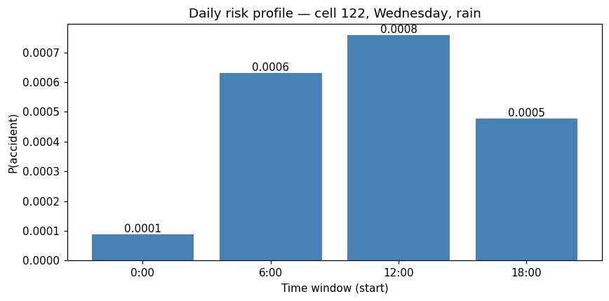

```python
hours_to_check = [0, 6, 12, 18]
profile = []

for h in hours_to_check:
    r = predictor.predict(
        time=f'2026-12-09 {h:02d}:00',
        cell_id=122,
        weather=weather_rain,
    )
    profile.append({'hour': h, 'risk': r['risk_probability'],
                    'lift': r['lift_over_baseline']})

profile_df = pd.DataFrame(profile)
print('Daily profile for cell 122 (Wednesday, rain):')
print(profile_df.to_string(index=False))

fig, ax = plt.subplots(figsize=(8, 4))
ax.bar(profile_df['hour'].astype(str) + ':00', profile_df['risk'], color='steelblue')
ax.set_xlabel('Time window (start)')
ax.set_ylabel('P(accident)')
ax.set_title('Daily risk profile — cell 122, Wednesday, rain')
for x, y in zip(range(len(profile_df)), profile_df['risk']):
    ax.text(x, y, f'{y:.4f}', ha='center', va='bottom')
plt.tight_layout()
plt.show()
```

### 9.3 Weather comparison — dry vs snow vs rain

Cell 122, Wednesday 12:00, varying weather conditions.

```python
scenarios = {
    'Clear (summer)': {
        'temperature_2m': 22, 'apparent_temperature': 22,
        'precipitation': 0, 'rain': 0, 'snow_depth': 0,
        'wind_speed_10m': 8, 'wind_gusts_10m': 12,
        'cloud_cover': 20, 'relative_humidity_2m': 55,
        'dew_point_2m': 12, 'surface_pressure': 1015, 'weather_code': 0,
    },
    'Drizzle (autumn)': {
        'temperature_2m': 10, 'apparent_temperature': 8,
        'precipitation': 0.8, 'rain': 0.8, 'snow_depth': 0,
        'wind_speed_10m': 12, 'wind_gusts_10m': 18,
        'cloud_cover': 75, 'relative_humidity_2m': 85,
        'dew_point_2m': 8, 'surface_pressure': 1012, 'weather_code': 51,
    },
    'Heavy rain': weather_rain,
    'Snow + wind': {
        'temperature_2m': -2, 'apparent_temperature': -8,
        'precipitation': 1.5, 'rain': 0, 'snow_depth': 0.05,
        'wind_speed_10m': 15, 'wind_gusts_10m': 28,
        'cloud_cover': 95, 'relative_humidity_2m': 90,
        'dew_point_2m': -3, 'surface_pressure': 1005, 'weather_code': 73,
    },
    'Frost (dry)': {
        'temperature_2m': -8, 'apparent_temperature': -12,
        'precipitation': 0, 'rain': 0, 'snow_depth': 0.02,
        'wind_speed_10m': 6, 'wind_gusts_10m': 9,
        'cloud_cover': 30, 'relative_humidity_2m': 80,
        'dew_point_2m': -10, 'surface_pressure': 1020, 'weather_code': 0,
    },
}

results = []
for name, w in scenarios.items():
    r = predictor.predict(time='2026-12-09 16:00', cell_id=122, weather=w)
    results.append({
        'scenario': name,
        'risk': r['risk_probability'],
        'lift': r['lift_over_baseline'],
    })

df_scen = pd.DataFrame(results)
print('Cell 122, Wednesday 12:00, different weather conditions:')
print(df_scen.to_string(index=False))
```

```
Cell 122, Wednesday 12:00, different weather conditions:
        scenario     risk     lift
  Clear (summer) 0.002704 7.837859
Drizzle (autumn) 0.001382 4.007068
      Heavy rain 0.000758 2.197435
     Snow + wind 0.001113 3.225158
     Frost (dry) 0.001903 5.517316
```

### 9.4 City heatmap for a given time window

`predict_grid` returns a DataFrame with risk_probability for all 494 cells. We visualize it as a scatter plot (each cell = one point).

```
Predictions for 494 cells
Top 10 highest risk:
 cell_id    centroid_x    centroid_y  risk_probability
     147 204502.142657 627530.061531          0.000677
     122 203502.142657 627530.061531          0.000630
     146 204502.142657 626530.061531          0.000630
     148 204502.142657 628530.061531          0.000544
     121 203502.142657 626530.061531          0.000424
     123 203502.142657 628530.061531          0.000285
     174 205502.142657 628530.061531          0.000265
     149 204502.142657 629530.061531          0.000262
     120 203502.142657 625530.061531          0.000211
      99 202502.142657 628530.061531          0.000179
```

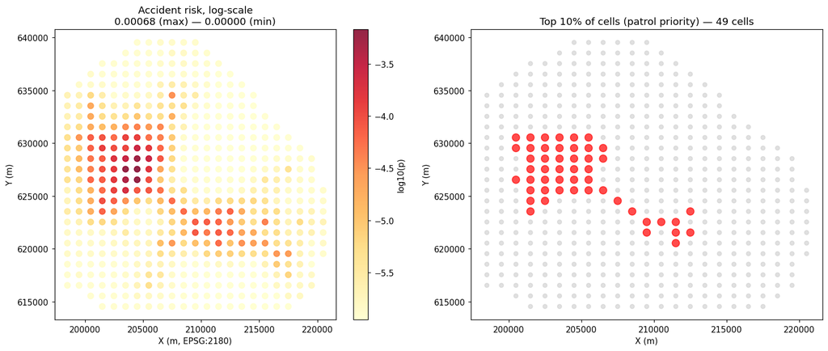

```python
# Prediction for the whole city — Wednesday 14:00 with rain
grid = predictor.predict_grid(time='2026-12-09 08:00', weather=weather_rain)

print(f'Predictions for {len(grid)} cells')
print(f'Top 10 highest risk:')
print(grid.head(10).to_string(index=False))

fig, axes = plt.subplots(1, 2, figsize=(14, 6))

# Left: heatmap with log-scale (greater contrast)
sc = axes[0].scatter(grid['centroid_x'], grid['centroid_y'],
                     c=np.log10(grid['risk_probability'] + 1e-8),
                     cmap='YlOrRd', s=50, alpha=0.85)
axes[0].set_title(f'Accident risk, log-scale\n{grid.iloc[0]["risk_probability"]:.5f} (max) — '
                  f'{grid.iloc[-1]["risk_probability"]:.5f} (min)')
axes[0].set_xlabel('X (m, EPSG:2180)')
axes[0].set_ylabel('Y (m)')
plt.colorbar(sc, ax=axes[0], label='log10(p)')

# Right: top 10% of cells (patrol priority)
top10pct_n = max(1, len(grid) // 10)
top_set = set(grid.head(top10pct_n)['cell_id'])
colors = ['red' if c in top_set else 'lightgray' for c in grid['cell_id']]
sizes = [80 if c in top_set else 25 for c in grid['cell_id']]
axes[1].scatter(grid['centroid_x'], grid['centroid_y'], c=colors, s=sizes, alpha=0.7)
axes[1].set_title(f'Top 10% of cells (patrol priority) — {top10pct_n} cells')
axes[1].set_xlabel('X (m)')
axes[1].set_ylabel('Y (m)')

plt.tight_layout()
plt.show()
```

```
Predictions for 494 cells
Top 10 highest risk:
 cell_id    centroid_x    centroid_y  risk_probability
     146 204502.142657 626530.061531          0.000101
     122 203502.142657 627530.061531          0.000087
     147 204502.142657 627530.061531          0.000083
     148 204502.142657 628530.061531          0.000040
     121 203502.142657 626530.061531          0.000028
     123 203502.142657 628530.061531          0.000023
     174 205502.142657 628530.061531          0.000020
     173 205502.142657 627530.061531          0.000019
     149 204502.142657 629530.061531          0.000017
     120 203502.142657 625530.061531          0.000017
```

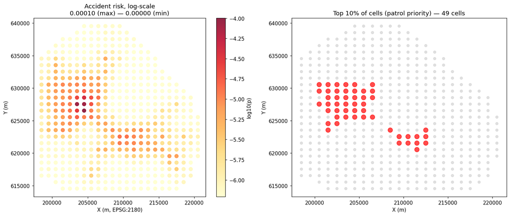

```python
# Prediction for the whole city — Wednesday 02:00 with rain
grid = predictor.predict_grid(time='2026-12-09 02:00', weather=weather_rain)

print(f'Predictions for {len(grid)} cells')
print(f'Top 10 highest risk:')
print(grid.head(10).to_string(index=False))

fig, axes = plt.subplots(1, 2, figsize=(14, 6))

# Left: heatmap with log-scale (greater contrast)
sc = axes[0].scatter(grid['centroid_x'], grid['centroid_y'],
                     c=np.log10(grid['risk_probability'] + 1e-8),
                     cmap='YlOrRd', s=50, alpha=0.85)
axes[0].set_title(f'Accident risk, log-scale\n{grid.iloc[0]["risk_probability"]:.5f} (max) — '
                  f'{grid.iloc[-1]["risk_probability"]:.5f} (min)')
axes[0].set_xlabel('X (m, EPSG:2180)')
axes[0].set_ylabel('Y (m)')
plt.colorbar(sc, ax=axes[0], label='log10(p)')

# Right: top 10% of cells (patrol priority)
top10pct_n = max(1, len(grid) // 10)
top_set = set(grid.head(top10pct_n)['cell_id'])
colors = ['red' if c in top_set else 'lightgray' for c in grid['cell_id']]
sizes = [80 if c in top_set else 25 for c in grid['cell_id']]
axes[1].scatter(grid['centroid_x'], grid['centroid_y'], c=colors, s=sizes, alpha=0.7)
axes[1].set_title(f'Top 10% of cells (patrol priority) — {top10pct_n} cells')
axes[1].set_xlabel('X (m)')
axes[1].set_ylabel('Y (m)')

plt.tight_layout()
plt.show()
```

## 10. Saving artifacts

The predictor saves:

- `model.json` — raw XGBoost model
- `feature_store.pkl` — snapshot of per-cell statistics
- `feature_names.json` — feature order (critical for inference)

Total ~1-5 MB. In production we load it via `AccidentRiskPredictor.load(path)`.

```python
predictor.save(ARTIFACT_DIR)

import os
print(f'Saved in: {ARTIFACT_DIR.resolve()}')
for f in sorted(os.listdir(ARTIFACT_DIR)):
    p = ARTIFACT_DIR / f
    size_kb = p.stat().st_size / 1024
    print(f'  {f}: {size_kb:,.1f} KB')

# Fix: Ensure we use the same prediction logic by updating the load method to use the Classifier wrapper
# For the sake of this cell, we will re-load manually to verify
import pickle, json
import xgboost as xgb

def fixed_load(path):
    path = Path(path)
    # Use XGBClassifier instead of raw Booster to keep logic consistent
    model = xgb.XGBClassifier()
    model.load_model(str(path / 'model.json'))
    with open(path / 'feature_store.pkl', 'rb') as f:
        fs = pickle.load(f)
    with open(path / 'feature_names.json') as f:
        feature_names = json.load(f)
    return AccidentRiskPredictor(model, fs, feature_names)

# Test roundtrip
predictor_loaded = fixed_load(ARTIFACT_DIR)
r1 = predictor.predict(time='2026-12-09 14:00', cell_id=122, weather=weather_rain)
r2 = predictor_loaded.predict(time='2026-12-09 14:00', cell_id=122, weather=weather_rain)

print(f'Original: {r1["risk_probability"]:.6f}')
print(f'Loaded:   {r2["risk_probability"]:.6f}')

assert abs(r1['risk_probability'] - r2['risk_probability']) < 1e-6
print(f'\n[OK] Save/load roundtrip matches exactly!')
```

```
Saved in: /content/production_artifact
  feature_names.json: 1.1 KB
  feature_store.pkl: 294.6 KB
  model.json: 659.3 KB
Original: 0.000758
Loaded:   0.000758

[OK] Save/load roundtrip matches exactly!
```